# Data Wrangling and Visualisation

13/02/2018

## Before there was R, there was S!

**R** is a dialect of **S** language that was developed in 1976 by *Rick Becker* and *John Chambers* at the Bell Laboratories.

*Rick Becker* gave an excellent keynote talk *"Forty Years of S"* at UseR!2016 conference:  
[Rick Becker @ UseR!2016](http://blog.revolutionanalytics.com/2016/07/rick-becker-s-talk.html) where he talked about development of **S** language that gives explanations for many characteristics of **R** as we know it, including "<-" assignment operator.

1993 Bell Labs gave StatSci (later Insightful Corp.) an exclusive license to develop and sell the **S** language. Insightful sold its implementation of the **S** language under the product name **S-PLUS**.

You can read more about the [history of S, R, and S-PLUS](https://www.whoishostingthis.com/resources/s-plus/)

## then, R was born

In early nineties at the University of Aucklandn in the Department of Statistics **R** was created by *Ross Ihaka* and *Robert Gentleman*.

They used [GNU General Public License](http://www.gnu.org/licenses/gpl-2.0.html) to make R open source free software.

**R**oss Ihaka and **R**obert Gentleman. *R: A language for data analysis and graphics.* Journal of Computational and Graphical Statistics, 5(3):299–314, 1996

Currently **R** is developed by the **R Development Core Team**, of which *John Chambers* is a member.

## Write R Code

To start using **R** you need to:

1. Install [R](https://cran.r-project.org/) [(and RStudio)](https://www.rstudio.com/products/rstudio/download/#download)
2. Launch it and set your working directory: letting R know where to find all of your files.
3. Start writing **R** code!

**Tip**: When start working on a new R code/R Project in [RStudio IDE](https://support.rstudio.com/hc/en-us/sections/200107586-Using-the-RStudio-IDE) use `File -> New Project`. This way your working directory would be set up when you start a new project and it will save all your files in it. Next time you open your project it would set project's directory as a working directory… It would help you with so much [more](https://support.rstudio.com/hc/en-us/articles/200526207-Using-Projects).

## Before Tidyverse R, there is Base R!

When you download and install **R** for the first time, you are installing **the Base R** software. **Base R** contains most of the functions you’ll use on a daily basis: `mean()`, `subset()`…

To learn about **R**'s basic operations, data structures and base functions you could look at one of R-Ladies Manchester's handouts: [Introduction to base R](https://tanjakec.github.io/blog/introduction-to-r/).

If you want to access data and code written by other people, you’ll need to install it as a **package**. An **R package** is a bundle of functions (code), data, documentation, vignettes (examples), stored in one neat place.

"In **R**, the fundamental unit of shareable code is the package." [Hadley Wickham](http://r-pkgs.had.co.nz/intro.html)

## The verse!

An opinionated collection of **R packages** for data science.

[`install.packages("tidyverse")`](https://www.tidyverse.org/)

[`library(tidyverse)`](https://www.tidyverse.org/packages/)

- Have you tried learning data science by reading books?

[**R for Data Science**](http://r4ds.had.co.nz/) by Garrett Grolemund & Hadley Wickham

- Have you tried learning data science by posting your questions and discussing it with other people within the R community?

[RStudio Community](https://community.rstudio.com/)

## The `dplyr` Package:

provides a “grammar” (the verbs) for data manipulation and for operating on data frames. The **key opertor and the esential verbs** are :

- `%>%`: **the “pipe” operator** used to connect multiple verb actions together into a pipeline.
- `select()`: return a subset of the columns of a data frame.
- `mutate()`: add new variables/columns or transform existing variables.
- `filter()`: extract a subset of rows from a data frame based on logical conditions.
- `arrange()`: reorder rows of a data frame according to single or multiple variables.
- `summarise()` / `summarize()`: reduces each group to a single row by calculating aggregate measures.

## Chicago Data

**Description:** Chicago daily air pollution and death rate data. A data frame with 7 columns and 5114 rows. Each row refers to one day. The columns are:

• `death` total deaths (per day).

• `pm10median` median particles in 2.5-10 per cubic m

• `pm25median` medianparticles < 2.5 mg per cubic m (more dangerous).

• `o3median` Ozone in parts per billion

• `so2median` Median Sulpher dioxide measurement

• `time` time in days

• `tmpd` temperature in fahrenheit

## 1st look at the data: `dim()` & `head()`

```r
# install.packages("gamair")
library(gamair)
data(chicago)
dim(chicago)
```

```
## [1] 5114    7
```

```r
head(chicago)
```

```
##   death pm10median pm25median  o3median  so2median    time tmpd
## 1   130 -7.4335443         NA -19.59234  1.9280426 -2556.5 31.5
## 2   150         NA         NA -19.03861 -0.9855631 -2555.5 33.0
## 3   101 -0.8265306         NA -20.21734 -1.8914161 -2554.5 33.0
## 4   135  5.5664557         NA -19.67567  6.1393413 -2553.5 29.0
## 5   126         NA         NA -19.21734  2.2784649 -2552.5 32.0
## 6   130  6.5664557         NA -17.63400  9.8585839 -2551.5 40.0
```

## Examine the structure of the data: `str()`

```r
str(chicago)
```

```
## 'data.frame':    5114 obs. of  7 variables:
##  $ death     : int  130 150 101 135 126 130 129 109 125 153 ...
##  $ pm10median: num  -7.434 NA -0.827 5.566 NA ...
##  $ pm25median: num  NA NA NA NA NA NA NA NA NA NA ...
##  $ o3median  : num  -19.6 -19 -20.2 -19.7 -19.2 ...
##  $ so2median : num  1.928 -0.986 -1.891 6.139 2.278 ...
##  $ time      : num  -2556 -2556 -2554 -2554 -2552 ...
##  $ tmpd      : num  31.5 33 33 29 32 40 34.5 29 26.5 32.5 ...
```

The output could look messy and it might not fit the screen if you're dealing with a big data set that has lots of variables!

## Do it in a tidy way: `glimpse()`

```r
suppressPackageStartupMessages(library(dplyr))
glimpse(chicago)
```

```
## Observations: 5,114
## Variables: 7
## $ death      <int> 130, 150, 101, 135, 126, 130, 129, 109, 125, 153, 1...
## $ pm10median <dbl> -7.4335443, NA, -0.8265306, 5.5664557, NA, 6.566455...
## $ pm25median <dbl> NA, NA, NA, NA, NA, NA, NA, NA, NA, NA, NA, NA, NA,...
## $ o3median   <dbl> -19.592338, -19.038614, -20.217338, -19.675671, -19...
## $ so2median  <dbl> 1.9280426, -0.9855631, -1.8914161, 6.1393413, 2.278...
## $ time       <dbl> -2556.5, -2555.5, -2554.5, -2553.5, -2552.5, -2551....
## $ tmpd       <dbl> 31.5, 33.0, 33.0, 29.0, 32.0, 40.0, 34.5, 29.0, 26....
```

## The pipeline operater: `%>%`

**Left Hand Side (LHS)** `%>%` **Right Hand Side (RHS)**

`x %>% f(..., y)`  
`f(x,y)`

The "pipe" passes the **result** of the **LHS** as the 1st operator argument of the **function** on the **RHS**

`3 %>% sum(4)` <==> `sum(3, 4)`

`%>%` is very practical for chaining together multiple `dplyr` functions in a sequence of operations.

## `select()`

- `starts_with("X")` every name that starts with "X".
- `ends_with("X")` every name that ends with "X".
- `contains("X")` every name that contains "X".
- `matches("X")` every name that matches "X", where "X" can be a regular expression.
- `num_range("x", 1:5)` the variables named x01, x02, x03, x04, x05.
- `one_of(x)` => every name that appears in x, which should be a character vector.

[output not shown]

## Select your variables

```r
chicago_air_measurements <- select(chicago, ends_with("median"))
head(chicago_air_measurements, n = 1)
```

```
##   pm10median pm25median  o3median so2median
## 1  -7.433544         NA -19.59234  1.928043
```

```r
chicago_air_pm <- chicago[c("pm10median", "pm25median")]
head(chicago_air_pm, n = 1)
```

```
##   pm10median pm25median
## 1  -7.433544         NA
```

```r
chicago_air_pm2 <- select(chicago, starts_with("pm"))
head(chicago_air_pm2, n = 1)
```

```
##   pm10median pm25median
## 1  -7.433544         NA
```

## `mutate()`

For example, it would allow you to add to the data frame `df` a new column, `z`, which is the multiplication of the columns `x` and `y`:

`mutate(df, z = x * y)`

Let us convert °F into °C: T(°C) = (T(°F) - 32) × 5/9

```r
chicago2 <- mutate(chicago, tmpdc = round((tmpd - 32) / 1.8, digits = 1))
head(chicago2, n = 3)
```

```
##   death pm10median pm25median  o3median  so2median    time tmpd tmpdc
## 1   130 -7.4335443         NA -19.59234  1.9280426 -2556.5 31.5  -0.3
## 2   150         NA         NA -19.03861 -0.9855631 -2555.5 33.0   0.6
## 3   101 -0.8265306         NA -20.21734 -1.8914161 -2554.5 33.0   0.6
```

## `filter()`

There is a set of logical operators in **R** that you can use inside `filter()`:

- `x < y`: TRUE if `x` is less than `y`
- `x <= y`: TRUE if `x` is less than or equal to `y`
- `x == y`: TRUE if `x` equals `y`
- `x != y`: TRUE if `x` does not equal `y`
- `x >= y`: TRUE if `x` is greater than or equal to `y`
- `x > y`: TRUE if `x` is greater than `y`
- `x %in% c(a, b, c)`: TRUE if `x` is in the vector `c(a, b, c)`

## Filter your data

```r
high_death <- filter(chicago2, death > 200)
high_death
```

```
##   death pm10median pm25median  o3median  so2median  time tmpd tmpdc
## 1   226  20.941667         NA 29.703545  2.2685856 559.5 91.5  33.1
## 2   411  14.798103         NA 28.115091  0.6976599 560.5 86.0  30.0
## 3   287  -8.333333         NA 21.115009 -0.9330126 561.5 83.0  28.3
## 4   228  -3.232732         NA  5.649732 -2.3158882 562.5 78.5  25.8
```

```r
high_temp_death <- filter(chicago2, death > 200 & tmpdc >= 30)
high_temp_death
```

```
##   death pm10median pm25median o3median so2median  time tmpd tmpdc
## 1   226   20.94167         NA 29.70355 2.2685856 559.5 91.5  33.1
## 2   411   14.79810         NA 28.11509 0.6976599 560.5 86.0  30.0
```

## `arrange()`

is used to reorder rows of a **d**ata **f**rame (df) according to one of the variables/columns.

- If you pass `arrange()` a character variable, **R** will rearrange the rows in alphabetical order according to values of the variable.
- If you pass a factor variable, **R** will rearrange the rows according to the order of the levels in your factor (running `levels()` on the variable reveals this order).

## Arranging your data

```r
low_2_high <- arrange(chicago, death)
head(low_2_high, n = 4)
```

```
##   death pm10median pm25median   o3median   so2median    time tmpd
## 1    69  -1.818182         NA  -8.029279  1.12452237  1313.5 64.5
## 2    73 -19.320548         NA  -5.869187  0.07297014  2052.5 66.0
## 3    77  -8.801262         NA -13.170360 -3.48994781 -2363.5 64.5
## 4    77 -19.165746  -10.14961   3.436157  3.60026234  1646.5 70.0
```

```r
high_2_low <- arrange(chicago, desc(death))
head(high_2_low, n = 4)
```

```
##   death pm10median pm25median  o3median  so2median  time tmpd
## 1   411  14.798103         NA 28.115091  0.6976599 560.5 86.0
## 2   287  -8.333333         NA 21.115009 -0.9330126 561.5 83.0
## 3   228  -3.232732         NA  5.649732 -2.3158882 562.5 78.5
## 4   226  20.941667         NA 29.703545  2.2685856 559.5 91.5
```

## `summarise()`

- uses the same syntax as `mutate()`, but the resulting dataset consists of a single row instead of an entire new column in the case of `mutate()`.
- builds a new dataset that contains only the summarising statistics.

Let us use `summarise()` to print out a summary of chicago data containing two variables: max_detht and the max_tmpd

```r
summarise(chicago, max_deth = max(death), max_tmpd = max(tmpd))
```

```
##   max_deth max_tmpd
## 1      411       92
```

## `%>%` all up!

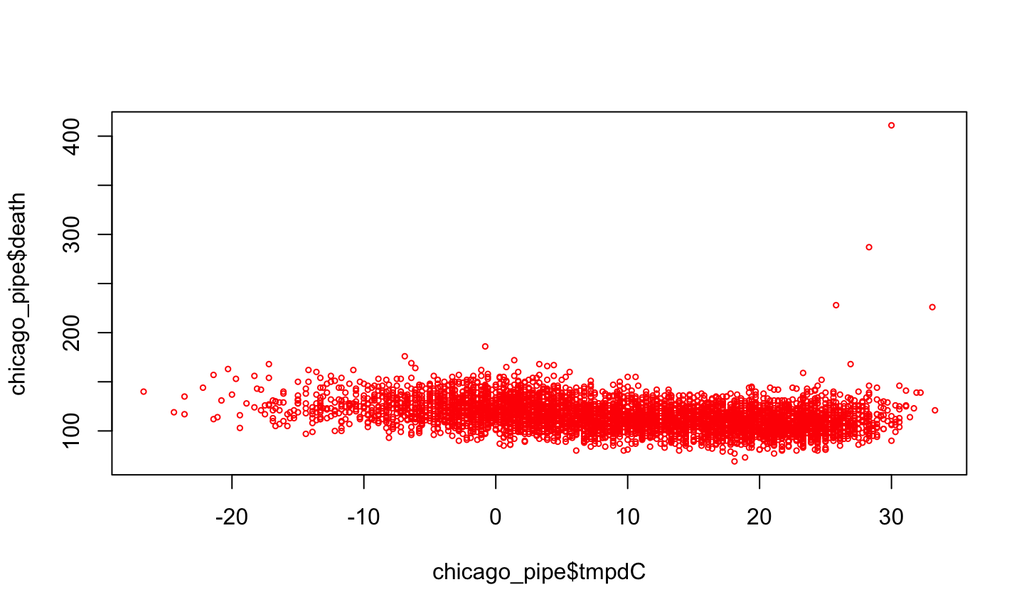

```r
chicago_pipe <- chicago %>%
  filter(!is.na(pm10median) & !is.na(so2median)) %>%
  mutate(tmpdC = round((tmpd - 32) / 1.8, digits = 1))
plot(chicago_pipe$tmpdC, chicago_pipe$death, cex = 0.5, col = "red")
```

## grammer of graphics

Enables you to specify building blocks of a plot and to combine them to create graphical display you want. There are 8 building blocks:

- data
- aesthetic mapping
- geometric object
- statistical transformations
- scales
- coordinate system
- position adjustments
- faceting

## `ggplot()`

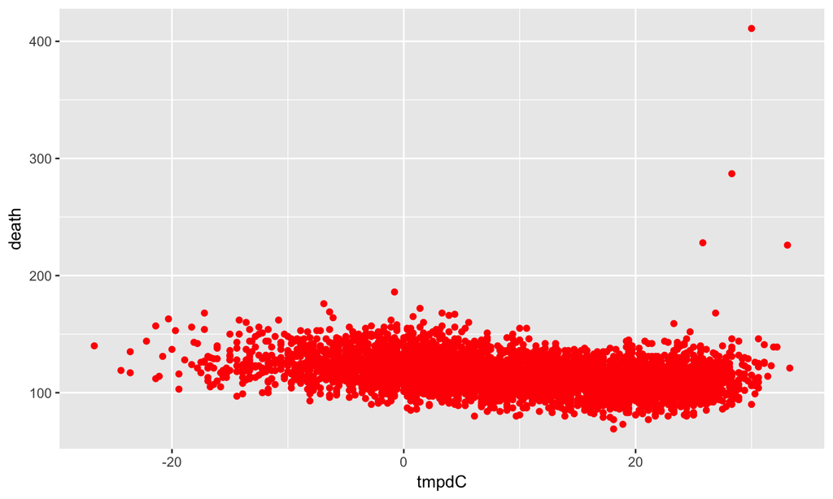

```r
library(ggplot2)
ggplot(chicago_pipe, aes(x = tmpdC, y = death)) +
  geom_point(col ="red")
```

## adding layers to your `ggplot()`

```r
ggplot(chicago_pipe, aes(x = tmpdC, y = death, col = "red")) +
  geom_point(alpha = 0.2) +
  geom_smooth(col = "blue") +
  labs (title= " death vs temperature ",
        x = "°C", y = "death") +
  theme(legend.position = "none",
        panel.border = element_rect(fill = NA,
                                    colour = "black",
                                    size = .75),
        plot.title=element_text(hjust=0.5))
```

## Voila

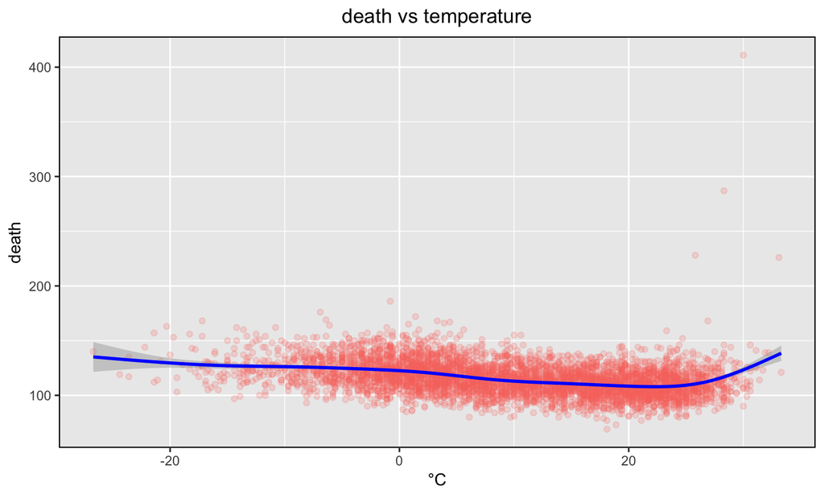

## useful links:

cheatsheets:

- [data-wrangling-cheatsheet](https://www.rstudio.com/wp-content/uploads/2015/02/data-wrangling-cheatsheet.pdf)
- [ggplot2-cheatsheet](https://www.rstudio.com/wp-content/uploads/2015/03/ggplot2-cheatsheet.pdf)

websites:

- [tidyverse, visualization, and manipulation basics](https://www.rstudio.com/resources/webinars/tidyverse-visualization-and-manipulation-basics/)
- [ggplot part of tidy verse](http://ggplot2.tidyverse.org/index.html)
- [Introduction to R graphics with ggplot2](http://tutorials.iq.harvard.edu/R/Rgraphics/Rgraphics.html#introduction)

## Your turn!

1. upload Daily Mortality Weather and Pollution Data for Chicago: **`chicagoNMMAPS`** available from **`dlnm`** package.
2. have a glance at the data.
3. what are the questions you could ask; could you provide the answers to them?

**There is a chalange:**

`dplyr`'s `group_by()` function enables you to group your data. It allows you to create a separate df that splits the original df by a variable.

Knowing about `group_by()` function, coud you compute the average pollutant level by month and visualise your result?

## Possible Solution: code

```r
# install and open `dlnm' package and access the data
install.packages("dlnm")
library(dlnm)
data("chicagoNMMAPS")

# group data by month and calculate average monthly polution
my_ch <- chicagoNMMAPS %>%
  group_by(month) %>%
  summarise(pm10 = mean(pm10, na.rm = TRUE))

# visualise the information
ggplot(my_ch, aes(x=month, y = pm10)) +
  geom_line() + geom_point(col = "red") +
  xlab("Month") + ylab("average pm10") +
  scale_x_continuous(breaks = seq(1, 12, 1), labels = seq(1, 12, 1))
```

## Avoid Chicago in spring and summer!

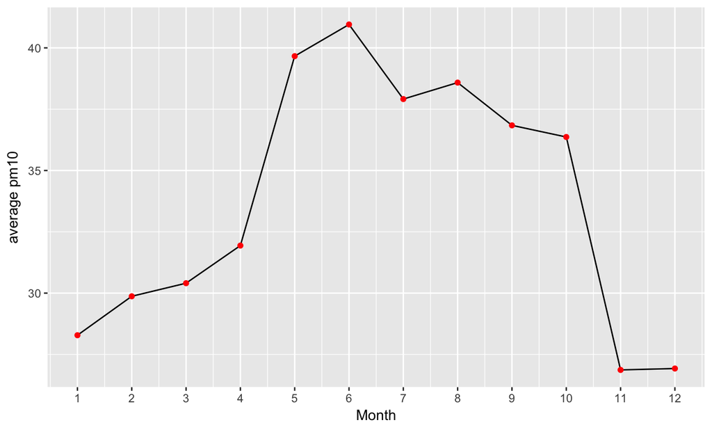